# Modelo Share of Market

# Ajuste de modelo de regresión lineal con enfoque bayesiano

## Introducción

Un modelo de market share busca encontrar qué variables afectan de manera relevante la participación de mercado de una empresa. El sentido común sugiere que habrá un alto grado de correlación entre la concentración del mercado y la participación de mercado y, de hecho, al menos algunos de los estudios han encontrado este problema.

## Objetivo

El objetivo de este proyecto es encontrar un modelo de market share adecuado para los datos de la empresa.

## Datos

Contamos con una base de datos con la informacion mensual de ventas en unidades así como otras variables para cada país durante el periodo abril 2017 - abril 2020. Las variables disponibles son

1. Fecha
2. País: CAM (Total Centroamérica), CR (Costa Rica), EL (El Salvador), GT (Guatemala), HD (Honduras), NIC (Nicaragua) y PTY (Panamá)
3. Distribución numérica (dist_num_A): Refleja el total de puntos de distribución en los que se encuentra disponible el producto para el fabricante A
4. Agotamientos (agot_num_A): Refleja el total de puntos por concepto de falta de producto en el punto de venta a causa de una demanda alta para el fabricante A
5. Ventas unidades (ventas_unidades_A): Volumen total de venta mensual en unidades (piezas) correspondiente al fabricante A
6. Precio por unidad (ppu_A): Precio en dólares del producto por unidad para el fabricante A.
7. Inventarios (inventarios_A): Total de producto en inventario del fabricante A
8. Share (share_A): Participación de mercado en ese mes para ese país del fabricante A
9. Inversión en promociones (inversion_promos_A): Monto en dólares destinado en dicho mes por concepto de ejecución de estrategias comerciales promocionales para el fabricante A
10. Inversión en promociones TV (inversion_promos_tv_A): Monto en dólares destinado en dicho mes por concepto de ejecución de estrategias comerciales promocionales en televisión abierta para el fabricante A.

Las variables dist_num_B, agot_num_B, ventas_unidades_B, ppu_B, inventarios_B y share_B son el equivalente de las antes mencionadas para el fabricante B.

## Análisis Exploratorio

### Identificación del tipo de variables

Observamos la estructura de los datos y sus principales estadísticos

```
## Rows: 259
## Columns: 16
## $ fecha                 <chr> "01/04/17", "01/05/17", "01/06/17", "01/07/17...
## $ pais                  <chr> "CAM", "CAM", "CAM", "CAM", "CAM", "CAM", "CA...
## $ dist_num_A            <dbl> 376, 384, 384, 382, 381, 378, 373, 369, 369, ...
## $ agot_num_A            <dbl> 26, 25, 26, 27, 25, 29, 36, 27, 25, 28, 25, 2...
## $ ventas_unidades_A     <dbl> 17279800, 17460500, 17427000, 17037600, 16967...
## $ ppu_A                 <dbl> 3.536826, 3.533928, 3.518911, 3.523688, 3.509...
## $ inventarios_A         <dbl> 22897400, 23459200, 23507900, 23337800, 22914...
## $ share_A               <dbl> 0.3160064, 0.3204379, 0.3291883, 0.3240030, 0...
## $ inversion_promos_A    <dbl> 0, 0, 0, 0, 0, 0, 0, 0, 0, 0, 0, 0, 0, 0, 0, ...
## $ inversion_promos_tv_A <dbl> 0, 0, 0, 0, 0, 0, 0, 0, 0, 0, 0, 0, 0, 0, 0, ...
## $ dist_num_B            <dbl> 430, 430, 429, 432, 430, 427, 424, 417, 417, ...
## $ agot_num_B            <dbl> 26, 25, 31, 27, 26, 28, 29, 25, 22, 32, 28, 2...
## $ ventas_unidades_B     <dbl> 29490500, 29419900, 28066400, 27994900, 27462...
## $ ppu_B                 <dbl> 3.213198, 3.240403, 3.229764, 3.255219, 3.262...
## $ inventarios_B         <dbl> 31090700, 30847700, 29363700, 30051800, 31829...
## $ share_B               <dbl> 0.5393111, 0.5399187, 0.5301619, 0.5323773, 0...
```

```
##     fecha               pais             dist_num_A      agot_num_A
##  Length:259         Length:259         Min.   : 40.0   Min.   : 1.000
##  Class :character   Class :character   1st Qu.: 49.0   1st Qu.: 3.000
##  Mode  :character   Mode  :character   Median : 68.0   Median : 4.000
##                                        Mean   :107.6   Mean   : 7.305
##                                        3rd Qu.: 82.0   3rd Qu.: 6.000
##                                        Max.   :384.0   Max.   :36.000
##  ventas_unidades_A      ppu_A       inventarios_A         share_A
##  Min.   :  850900   Min.   :2.023   Min.   : 1484700   Min.   :0.2118
##  1st Qu.: 1974450   1st Qu.:3.027   1st Qu.: 2440300   1st Qu.:0.2656
##  Median : 3063800   Median :3.401   Median : 3950900   Median :0.3297
##  Mean   : 4601843   Mean   :3.622   Mean   : 5992498   Mean   :0.3392
##  3rd Qu.: 3628900   3rd Qu.:4.775   3rd Qu.: 5211750   3rd Qu.:0.4095
##  Max.   :17460500   Max.   :5.292   Max.   :23507900   Max.   :0.5208
##  inversion_promos_A inversion_promos_tv_A   dist_num_B      agot_num_B
##  Min.   :     0     Min.   :     0        Min.   : 52.0   Min.   : 0.000
##  1st Qu.:     0     1st Qu.:     0        1st Qu.: 61.0   1st Qu.: 4.000
##  Median :     0     Median :     0        Median : 76.0   Median : 5.000
##  Mean   :  2885     Mean   :  2497        Mean   :119.9   Mean   : 7.552
##  3rd Qu.:     0     3rd Qu.:     0        3rd Qu.: 82.0   3rd Qu.: 6.000
##  Max.   :171398     Max.   :166118        Max.   :432.0   Max.   :32.000
##  ventas_unidades_B      ppu_B       inventarios_B         share_B
##  Min.   :  777000   Min.   :2.102   Min.   : 1579300   Min.   :0.2706
##  1st Qu.: 2716650   1st Qu.:2.896   1st Qu.: 2648400   1st Qu.:0.3699
##  Median : 4788000   Median :3.196   Median : 5227200   Median :0.5361
##  Mean   : 7293549   Mean   :3.432   Mean   : 8292449   Mean   :0.5062
##  3rd Qu.: 6837550   3rd Qu.:4.018   3rd Qu.: 9212300   3rd Qu.:0.5866
##  Max.   :29490500   Max.   :5.231   Max.   :32190900   Max.   :0.6719
```

La única variable por limpiar es “fecha” dado de que no es tipo fecha

```r
datos$fecha <- datos$fecha %>% dmy()
```

### Diagramas de dispersión

Para iniciar con la visualización de datos, observaremos de manera general los datos y con los resultados decidiremos si es necesaria una posterior segmentación de datos y subgrupos hasta tener una mayor claridad de relación entre variables.

Posteriormente, nos enfocaremos en aquellos resultados que muestren mayor relevancia.

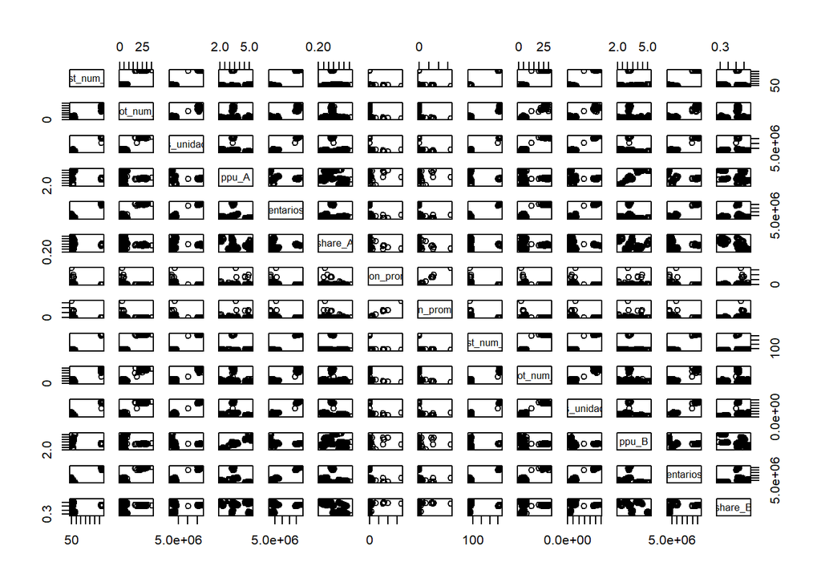

```r
pairs(datos[,3:16])
```

No se ve nada :( entonces hacemos varios gráficos, pero cada uno contra menos elementos

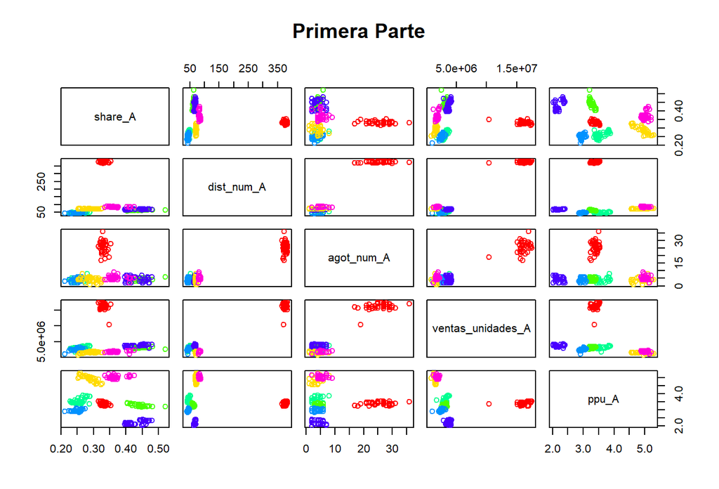

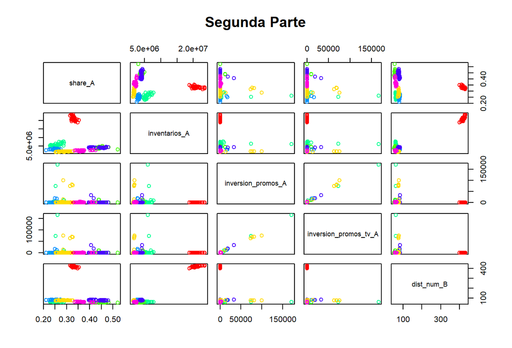

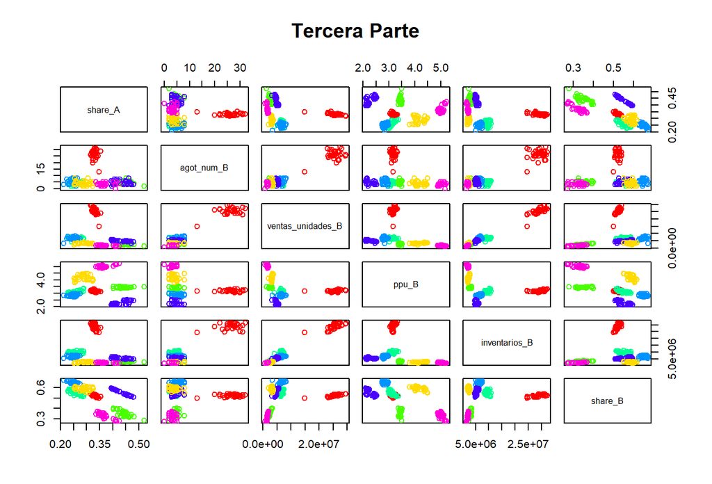

Podemos observar una mayor relación entre las variables si segmentamos los datos por país, por lo que segmentaremos el DataFrame original a distintos DataFrames por país y posteriormente relizaremos el análisis de correlación.

```r
#Los nombres de los DataFrames tendrán la siguiente estructura: "DF_" + ClavePais
assign(paste("DF",unique(paises)[1], sep = "_"), datos %>% filter(pais == unique(paises)[1]))
assign(paste("DF",unique(paises)[2], sep = "_"), datos %>% filter(pais == unique(paises)[2]))
assign(paste("DF",unique(paises)[3], sep = "_"), datos %>% filter(pais == unique(paises)[3]))
assign(paste("DF",unique(paises)[4], sep = "_"), datos %>% filter(pais == unique(paises)[4]))
assign(paste("DF",unique(paises)[5], sep = "_"), datos %>% filter(pais == unique(paises)[5]))
assign(paste("DF",unique(paises)[6], sep = "_"), datos %>% filter(pais == unique(paises)[6]))
assign(paste("DF",unique(paises)[7], sep = "_"), datos %>% filter(pais == unique(paises)[7]))
```

### Correlogramas

A continuación se presentan los resultados observados a partir de la creación de correlogramas por país.

Tomaremos especial atención a aquellas variables cuyo coeficiente de correlación sea lo suficientemente alto, i.e. >|.75| para poder hablar en el siguiente apartado de colinealidad.

### Total Centroamérica

- Alta correlación con las variables del fabricante B a excepción del agot_num_B.
- En cuanto a las variables propias del fabricante A, la de mayor correlación fueron los inventarios.
- Correlación(Share_A, Share_B) = -0.77

### Costa Rica

- La correlación con cada una de las variables del fabricante B es muy cercana a 0, a excepción de la variable inventarios_B que es .25
- Alta correlación con las variables propias del fabricante A, a excepción de la variable dist_num_A, la cual es cercana a 0.
- Correlación(Share_A, ppu_A) = -0.87

### El Salvador

- Sólo las variables inventarios_A y ppu_B muestran correlaciones cercanas a 0.
- Las variables ventas_unidades_B y ppu_A tienen correlación con la participación de mercado muy alta.
- Correlación(Share_A, ventas_unidades_B) = -0.8
- Correlación(Share_A, Share_B) = -0.8

### Guatemala

- Sólo las variables inventarios_B y ventas_unidades_B muestran correlaciones bajas.
- Correlación(Share_A, Share_B) = -0.76

### Honduras

- La única correlación sobrevaliente es la que se tiene con la variable ventas_unidades_A.

### Nicaragua

- Alta correlación con las variables del fabricante B.
- Correlación(Share_A, Share_B) = -1

### Panamá

- La correlación con cada variable del fabricante B se muestra alta a excepción de agot_num_B.
- En contraste, la correlación con las variables propias del fabricante A es baja a excepción de inventarios_A, ventas_unidades_A y ppu_A.
- Correlación(Share_a, Share_B) = -0.88

### Boxplots

Por último, realizamos boxplots para observar valores atípicos.

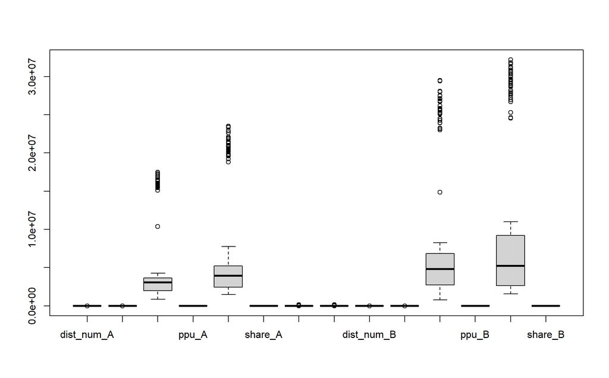

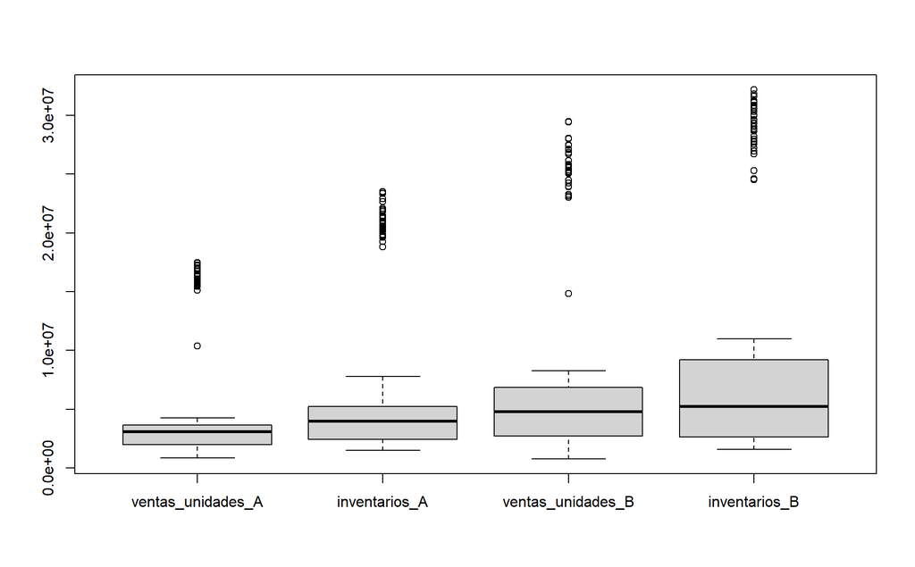

Podemos ver que las siguientes variables presentan una gran cantidad de datos atípicos.

1. *ventas_unidades_A*
2. *inventarios_A*
3. *ventas_unidades_B*
4. *inventarios_B*

### Colinealidad

Recordemos que la colinealidad es el fenomeno en el cual una variable independiente es una combinación lineal de otras variables. Es decir, existe un alto nivel de correlación (igual o cercana a 1) a tal grado que se pudiera decir que son en cierto grado dependientes.

Además, se observan resultados significativos para las variables:

1. *ppu_a* en Costa Rica
2. *ventas_unidades_B* en El Salvador

### Series de tiempo

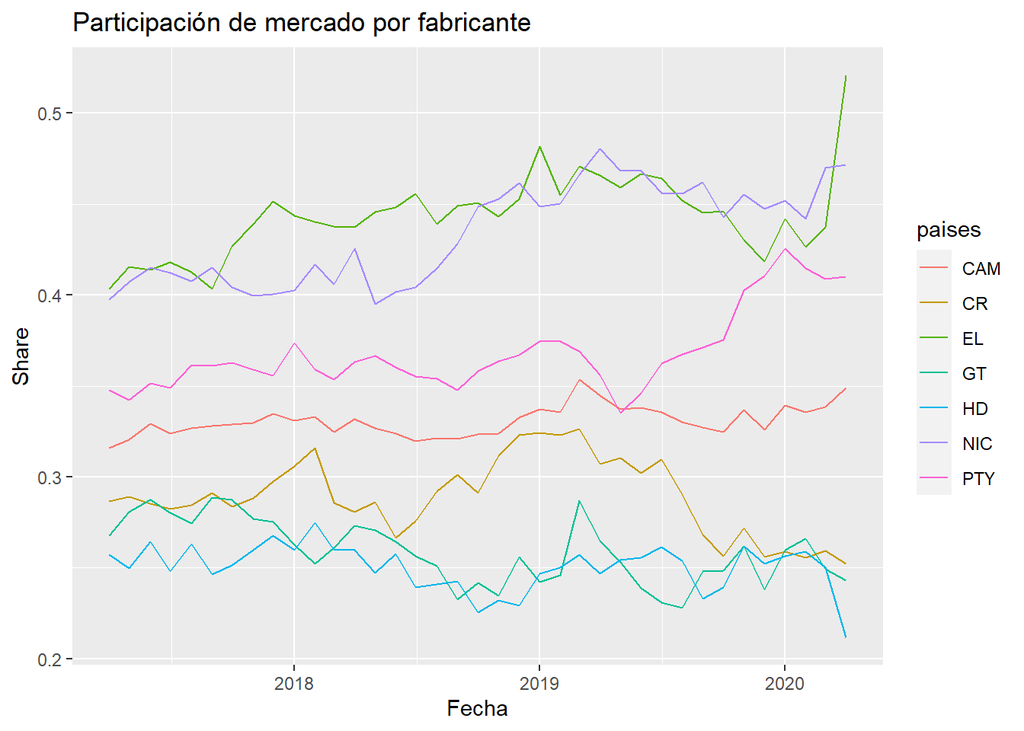

```r
ggplot(datos, aes(x = fecha, y = share_A, col = paises)) + geom_line() +
  labs(title = "Participación de mercado por fabricante", x = "Fecha",  y ="Share")
```

## Resultados de Análisis Exploratorio

### Resultados Generales

- Dada la alta correlación y dependencia lineal que existe entre la participación de mercado del fabricante A y la participación de mercado del fabricante B, optamos por suprimir dicha variable para el modelo de regresión para todos los paises.
- Se observa en la gráfica de participación de mercado a través del tiempo a dos grupos bien diferenciados con base en su nivel de market share. Denotaremos al primer grupo como aquel cuyos paises tienen niveles más bajos de participación de mercado y está compuesto por: {Honduras, Guatemala y Costa Rica}. Mientras que el segundo grupo será aquel con participaciones mayores: {El Salvador, Panamá y Nicaragua}. El primer grupo muestra un estancamiento en su crecimiento y en algunos casos, aunque no muy signicativo, un empeoramiento. Por el contrario, para el segundo grupo se muestra una tendencia a la alza con el paso del tiempo. Por lo que, en primera instancia, podemos suponer que las variables cuya mayor significancia tengan serán similares dentro de los paises por grupo. Es decir, El Salvador, Panamá y Nicaragua tendrán similares variables que están influyendo de manera positiva para el crecimiento de la participación de mercado … más adelante lo comprobaremos.

## Ajuste de modelos

Se considera la información disponible hasta octubre 2019 para el ajuste de modelos y el periodo de noviembre 2019 - abril 2020 para validar el modelo.

```r
datos_ajuste <- datos %>% filter(fecha <= "2019-10-01") %>% subset(select = -share_B)
datos_prueba <- datos %>% filter(fecha > "2019-10-01") %>% subset(select = -share_B)
```

## Modelos de regresión con enfoque bayesiano

Modelos de regresión con enfoque bayesiano para cada país. El reporte del modelo final debe considerar lo siguiente:

- Los modelos deben apegarse lo mejor posible a cumplir con los supuestos elementales de un modelo
- de regresión
- Debe indicar el tipo de información inicial que utilizó en cada caso
- Cerciorarse que la distribución final cumple con los supuestos necesarios
- Es de suma importancia que realice una selección de variables para preservar únicamente los regresores
- significativos en cada modelo
- De ser posible, intente mantener una estructura similar entre los modelos de cada país
- Los coeficientes de cada modelo deben ser comparables entre los regresores
- Reporte el nivel de ajuste y el nivel de error de cada modelo tomando como base el conjunto de prueba

Dado que la funcion jags requiere datos como lista, seleccionamos las variables que utlizaremos para la regresión y las guardamos en una lista.

La selección de variables será especializada para cada país. Nos apoyaremos con la metodología stepwise para la selección de variables. Y finalmente, tener un modelo por grupo para utilizar con la metodología JAGS.

Se utilizan distribuciones inicial no informativas para todos los paises.

### El Salvador

```r
#Datos train para El Salvador
train_EL <- datos_ajuste %>% filter(pais == "EL")
test_EL <- datos_prueba %>% filter(pais == "EL")

#Stepwise para ver cuales variables son las buenas
full_EL <- lm(share_A~., data = train_EL[,3:15])
step.model_EL <- stepAIC(full_EL, direction = "both", trace = FALSE)
summary(step.model_EL)
```

```
##
## Call:
## lm(formula = share_A ~ ventas_unidades_A + ventas_unidades_B +
##     ppu_B + inventarios_B, data = train_EL[, 3:15])
##
## Residuals:
##        Min         1Q     Median         3Q        Max
## -0.0108083 -0.0029784 -0.0002745  0.0041294  0.0098928
##
## Coefficients:
##                     Estimate Std. Error t value Pr(>|t|)
## (Intercept)        9.772e-02  1.033e-01   0.946   0.3530
## ventas_unidades_A  7.058e-08  8.408e-09   8.395 7.09e-09 ***
## ventas_unidades_B -6.301e-08  3.360e-09 -18.753  < 2e-16 ***
## ppu_B              7.379e-02  3.030e-02   2.435   0.0220 *
## inventarios_B      8.223e-09  3.570e-09   2.304   0.0295 *
## ---
## Signif. codes:  0 '***' 0.001 '**' 0.01 '*' 0.05 '.' 0.1 ' ' 1
##
## Residual standard error: 0.005084 on 26 degrees of freedom
## Multiple R-squared:  0.941,  Adjusted R-squared:  0.9319
## F-statistic: 103.6 on 4 and 26 DF,  p-value: 1.401e-15
```

```r
#Almacenamiento de variables
jags_EL <- list(
  share_A = train_EL$share_A,
  ventas_unidades_A = train_EL$ventas_unidades_A,
  ventas_unidades_B = train_EL$ventas_unidades_B,
  ppu_B = train_EL$ppu_B,
  inventarios_B = train_EL$inventarios_B,
  n = nrow(train_EL)
)

#Declaración distribuciones iniciales (no informativas)
jags.inits_EL <- function(){
  list(be = rep(0,5),
       tau = 1)
}

# Seleccionamos los parámetros a monitorear
jags_param_EL <- c("be", "pred")

# Asociamos variables con coeficientes

coef_variables <- data.frame(
  parametro = c(paste0('be_', 1:5)),
  variable = c('Intercepto',
               'ventas_unidades_A',
               'Ventas_unidades_B',
               'Precio_unidad_B',
               'Inventarios_B')
)


# Codigo
set.seed(17891521)
jags_model_EL <- jags(jags_EL, jags.inits_EL, jags_param_EL,
                   model.file = "libraries/modelo_fem_EL",
                   n.iter = 50000,
                   n.chains = 1,
                   n.thin = 1,
                   n.burnin = 5000)
```

```
## module glm loaded
```

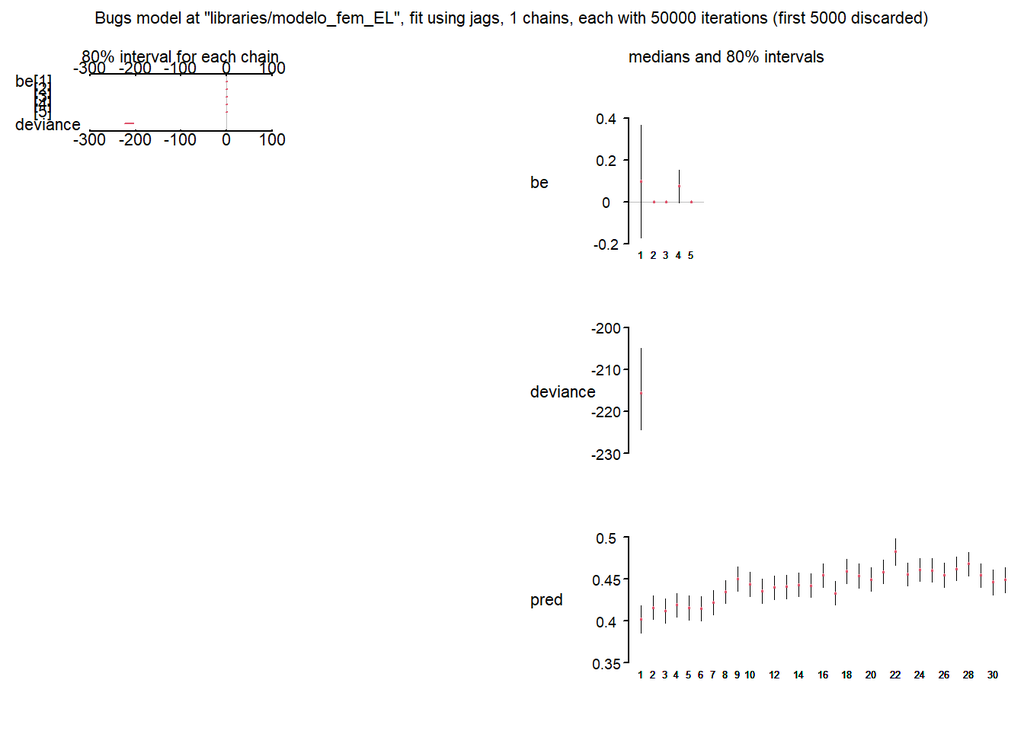

```r
#Ajuste del modelo
plot(jags_model_EL)
```

```r
jags_sims_EL <- jags_model_EL$BUGSoutput$sims.matrix %>% as.data.frame()

train_preds_EL <- jags_sims_EL %>%
  dplyr::select(contains("pred")) %>%
  gather(parametro, sim) %>%
  mutate(mu_num = as.numeric(str_extract(parametro, '[0-9]+'))) %>%
  group_by(mu_num) %>%
  summarise(q_1 = quantile(sim, probs = 0.05),
            q_5 = median(sim),
            q_9 = quantile(sim, probs = 0.95),
            media = mean(sim)) %>%
  ungroup %>%
  cbind(share = train_EL$share_A) %>%
  dplyr::select(share, media, q_1:q_9)
# Coeficientes y significancia

coeficientes <- jags_sims_EL %>%
  dplyr::select(contains('be')) %>%
  gather(parametro, sim) %>%
  group_by(parametro) %>%
  summarise(q_1 = quantile(sim, probs = 0.1),
            mediana = median(sim),
            q_9 = quantile(sim, probs = 0.9),
            media = mean(sim),
            probs = 100*prob(sim),
            varianza = var(sim)) %>%
  ungroup %>%
  mutate(aux_param = str_extract(parametro, '(\\d)+'),
         aux_param_2 = str_extract(parametro, '^([[:alpha:]]*)')) %>%
  mutate(parametro = paste(aux_param_2, aux_param, sep = '_')) %>%
  dplyr::select(-aux_param_2, -aux_param) %>%
  left_join(coef_variables)
coeficientes %>% drop_na %>% print(n = 90)
```

```
## # A tibble: 5 x 8
##   parametro      q_1  mediana         q_9    media   probs varianza variable
##   <chr>        <dbl>    <dbl>       <dbl>    <dbl>   <dbl>    <dbl> <chr>
## 1 be_1      -1.72e-1  9.73e-2     3.67e-1  9.64e-2 3.20e+1 4.75e- 2 Intercepto
## 2 be_2       4.86e-8  7.06e-8     9.25e-8  7.06e-8 1.78e-2 3.10e-16 ventas_unid~
## 3 be_3      -7.18e-8 -6.30e-8    -5.42e-8 -6.30e-8 2.22e-3 4.89e-17 Ventas_unid~
## 4 be_4      -4.93e-3  7.39e-2     1.53e-1  7.41e-2 1.15e+1 4.02e- 3 Precio_unid~
## 5 be_5      -1.02e-9  8.27e-9     1.76e-8  8.27e-9 1.26e+1 5.75e-17 Inventarios~
```

```r
# Métricas de ajuste

cor(train_preds_EL$q_5, train_preds_EL$share)^2
```

```
## [1] 0.9410223
```

```r
train_preds_EL %>%
  mutate(err = abs((q_5-share)/share)) %>%
  dplyr::select(err) %>%
  as.matrix %>%
  median
```

```
## [1] 0.007311855
```

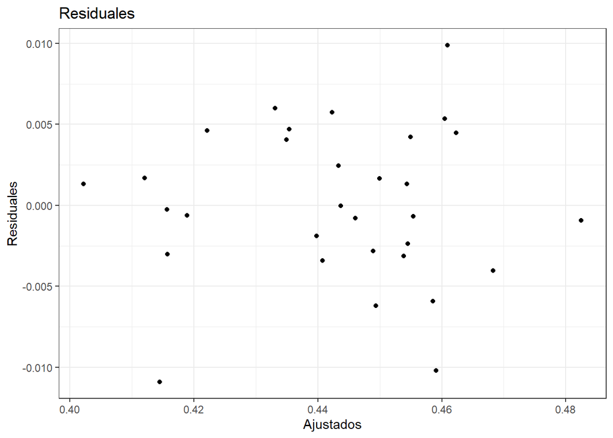

```r
# Análisis de residuales

train_res <- train_preds_EL %>%
  mutate(res = share - media)

train_res %>%
  ggplot(aes(media, res)) +
  geom_point() +
  labs(title = 'Residuales', x = 'Ajustados', y = 'Residuales') +
  theme_bw()
```

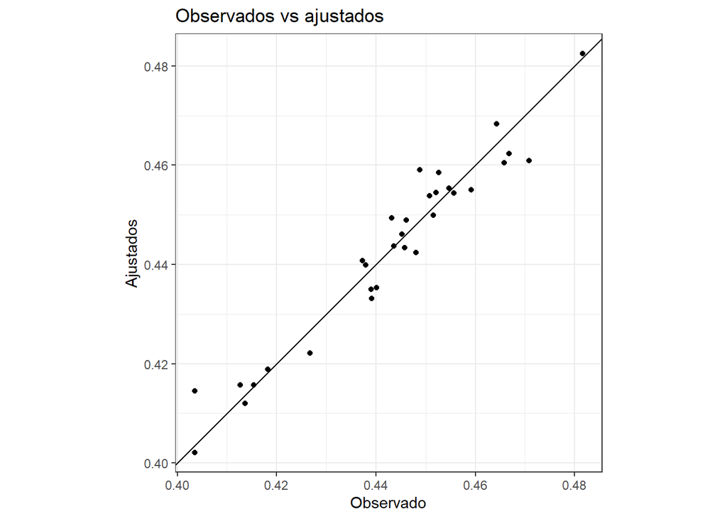

```r
# Gráfico de ajustados vs observados

train_preds_EL %>%
  ggplot(aes(share, q_5)) +
  geom_point() +
  geom_abline(intercept = 0, slope = 1) +
  coord_equal() +
  labs(title = 'Observados vs ajustados', x = 'Observado', y = 'Ajustados') +
  theme(legend.position = 'bottom') +
  theme_bw()
```

```r
#Prediccióm

train_EL2 <- train_EL %>%
  rbind(test_EL %>%
          mutate(share_A = NA))

jags_EL2 <- list(
  share_A = train_EL2$share_A,
  ventas_unidades_A = train_EL2$ventas_unidades_A,
  ventas_unidades_B = train_EL2$ventas_unidades_B,
  ppu_B = train_EL2$ppu_B,
  inventarios_B = train_EL2$inventarios_B,
  n = nrow(train_EL),
  m = nrow(test_EL)
)

#Parametros a guardar

jags_param_EL2 <- c("be", "pred")

#JAGS
set.seed(1789152)
jags_model_EL2 <- jags(jags_EL2, jags.inits_EL, jags_param_EL2,
                   model.file = "libraries/modelo_fem_pronostico_EL",
                   n.iter = 50000,
                   n.chains = 1,
                   n.thin = 1,
                   n.burnin = 5000)
jags_sims_EL2 <- jags_model_EL2$BUGSoutput$sims.matrix %>% as.data.frame()

train_preds_EL <- jags_sims_EL2 %>%
  dplyr::select(contains("pred")) %>%
  gather(parametro, sim) %>%
  mutate(mu_num = as.numeric(str_extract(parametro, '[0-9]+'))) %>%
  group_by(mu_num) %>%
  summarise(q_1 = quantile(sim, probs = 0.05),
            q_5 = median(sim),
            q_9 = quantile(sim, probs = 0.95),
            media = mean(sim)) %>%
  ungroup %>%
  cbind(share_A = train_EL2$share_A) %>%
  dplyr::select(share_A, media, q_1:q_9)
```

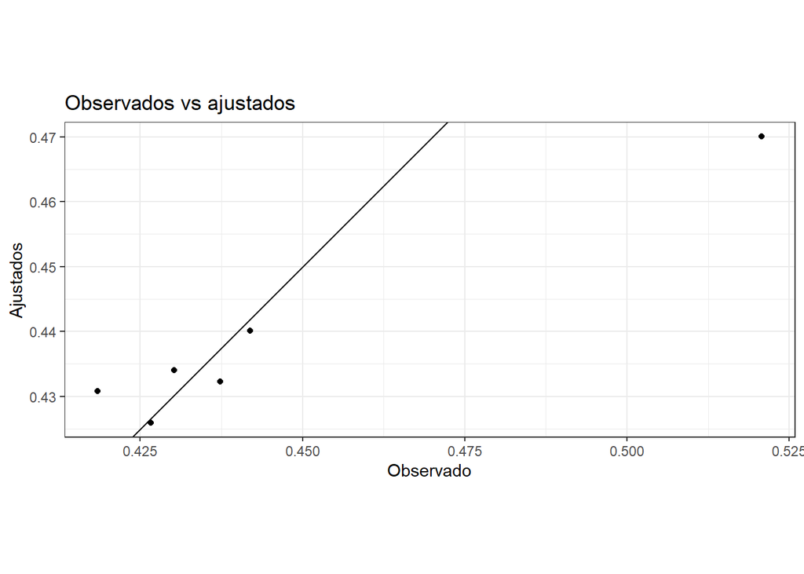

```r
ajuste_pronos_EL <- train_preds_EL %>%
  filter(is.na(share_A)) %>%
  dplyr::select(-share_A) %>%
  cbind(test_EL %>% dplyr::select(share_A)) %>%
  dplyr::select(share_A, q_5)

cor_EL <- cor(ajuste_pronos_EL$share_A, ajuste_pronos_EL$q_5)^2


ajuste_pronos_EL %>%
  ggplot(aes(share_A, q_5)) +
  geom_point() +
  geom_abline(intercept = 0, slope = 1) +
  coord_equal() +
  labs(title = 'Observados vs ajustados', x = 'Observado', y = 'Ajustados') +
  theme(legend.position = 'bottom') +
  theme_bw()
```

### Nicaragua

```r
#Datos train para El Salvador
train_NIC <- datos_ajuste %>% filter(pais == "NIC")
test_NIC <- datos_prueba %>% filter(pais == "NIC")

#Stepwise para ver cuales variables son las buenas
full_NIC <- lm(share_A~., data = train_NIC[,3:15])
step.model_NIC <- stepAIC(full_NIC, direction = "both", trace = FALSE)
summary(step.model_NIC)
```

```
##
## Call:
## lm(formula = share_A ~ ventas_unidades_A + ppu_A + inventarios_A +
##     ventas_unidades_B + ppu_B + inventarios_B, data = train_NIC[,
##     3:15])
##
## Residuals:
##        Min         1Q     Median         3Q        Max
## -2.274e-03 -8.192e-04 -1.929e-05  8.250e-04  2.107e-03
##
## Coefficients:
##                     Estimate Std. Error t value Pr(>|t|)
## (Intercept)        4.213e-01  9.738e-03  43.269   <2e-16 ***
## ventas_unidades_A  6.277e-08  1.418e-09  44.281   <2e-16 ***
## ppu_A             -2.289e-02  8.638e-03  -2.650   0.0140 *
## inventarios_A      3.846e-09  1.660e-09   2.317   0.0294 *
## ventas_unidades_B -4.618e-08  8.363e-10 -55.223   <2e-16 ***
## ppu_B              1.813e-02  8.355e-03   2.169   0.0402 *
## inventarios_B     -1.595e-09  8.881e-10  -1.796   0.0852 .
## ---
## Signif. codes:  0 '***' 0.001 '**' 0.01 '*' 0.05 '.' 0.1 ' ' 1
##
## Residual standard error: 0.001358 on 24 degrees of freedom
## Multiple R-squared:  0.998,  Adjusted R-squared:  0.9975
## F-statistic:  1958 on 6 and 24 DF,  p-value: < 2.2e-16
```

```r
#Almacenamiento de variables
jags_NIC <- list(
  share_A = train_NIC$share_A,
  ventas_unidades_A = train_NIC$ventas_unidades_A,
  ppu_A = train_NIC$ppu_A,
  inventarios_A = train_NIC$inventarios_A,
  ventas_unidades_B = train_NIC$ventas_unidades_B,
  ppu_B = train_NIC$ppu_B,
  inventarios_B = train_NIC$inventarios_B,
  n = nrow(train_NIC)
)

#Declaración distribuciones iniciales (no informativas)
jags.inits_NIC <- function(){
  list(be = rep(0,7),
       tau = 1)
}

# Seleccionamos los parámetros a monitorear
jags_param_NIC <- c("be", "pred")

# Asociamos variables con coeficientes

coef_variables <- data.frame(
  parametro = c(paste0('be_', 1:7)),
  variable = c('Intercepto',
               'ventas_unidades_A',
               'Precio_unidad_A',
               'inventarios_A',
               'Ventas_unidades_B',
               'Precio_unidad_B',
               'Inventarios_B')
)


# Codigo
set.seed(17891525)
jags_model_NIC <- jags(jags_NIC, jags.inits_NIC, jags_param_NIC,
                   model.file = "libraries/modelo_fem_NIC",
                   n.iter = 50000,
                   n.chains = 1,
                   n.thin = 1,
                   n.burnin = 5000)
```

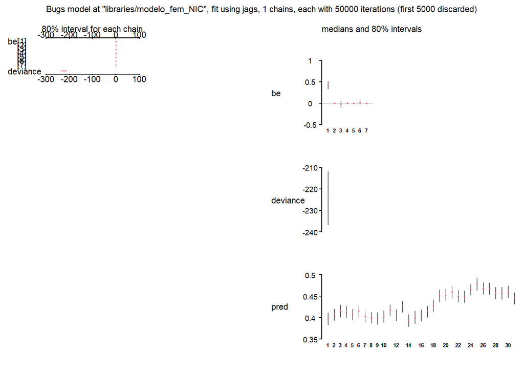

```r
#Ajuste del modelo
plot(jags_model_NIC)
```

```r
jags_sims_NIC <- jags_model_NIC$BUGSoutput$sims.matrix %>% as.data.frame()

train_preds <- jags_sims_NIC %>%
  dplyr::select(contains("pred")) %>%
  gather(parametro, sim) %>%
  mutate(mu_num = as.numeric(str_extract(parametro, '[0-9]+'))) %>%
  group_by(mu_num) %>%
  summarise(q_1 = quantile(sim, probs = 0.05),
            q_5 = median(sim),
            q_9 = quantile(sim, probs = 0.95),
            media = mean(sim)) %>%
  ungroup %>%
  cbind(share = train_NIC$share_A) %>%
  dplyr::select(share, media, q_1:q_9)
# Coeficientes y significancia

coeficientes <- jags_sims_NIC %>%
  dplyr::select(contains('be')) %>%
  gather(parametro, sim) %>%
  group_by(parametro) %>%
  summarise(q_1 = quantile(sim, probs = 0.1),
            mediana = median(sim),
            q_9 = quantile(sim, probs = 0.9),
            media = mean(sim),
            probs = 100*prob(sim),
            varianza = var(sim)) %>%
  ungroup %>%
  mutate(aux_param = str_extract(parametro, '(\\d)+'),
         aux_param_2 = str_extract(parametro, '^([[:alpha:]]*)')) %>%
  mutate(parametro = paste(aux_param_2, aux_param, sep = '_')) %>%
  dplyr::select(-aux_param_2, -aux_param) %>%
  left_join(coef_variables)
coeficientes %>% drop_na %>% print(n = 90)
```

```
## # A tibble: 7 x 8
##   parametro      q_1  mediana      q_9    media    probs varianza variable
##   <chr>        <dbl>    <dbl>    <dbl>    <dbl>    <dbl>    <dbl> <chr>
## 1 be_1       3.34e-1  4.21e-1  5.08e-1  4.21e-1  0.00667 6.47e- 3 Intercepto
## 2 be_2       5.01e-8  6.27e-8  7.55e-8  6.28e-8  0.00444 1.04e-16 ventas_unidad~
## 3 be_3      -1.00e-1 -2.28e-2  5.46e-2 -2.27e-2 34.9     4.37e- 3 Precio_unidad~
## 4 be_4      -1.11e-8  3.81e-9  1.86e-8  3.83e-9 37.2     1.75e-16 inventarios_A
## 5 be_5      -5.37e-8 -4.62e-8 -3.87e-8 -4.62e-8  0.00444 3.70e-17 Ventas_unidad~
## 6 be_6      -5.66e-2  1.82e-2  9.33e-2  1.80e-2 37.5     3.84e- 3 Precio_unidad~
## 7 be_7      -9.54e-9 -1.57e-9  6.43e-9 -1.55e-9 39.8     4.77e-17 Inventarios_B
```

```r
# Métricas de ajuste

cor(train_preds$q_5, train_preds$share)^2
```

```
## [1] 0.997942
```

```r
train_preds %>%
  mutate(err = abs((q_5-share)/share)) %>%
  dplyr::select(err) %>%
  as.matrix %>%
  median
```

```
## [1] 0.002074668
```

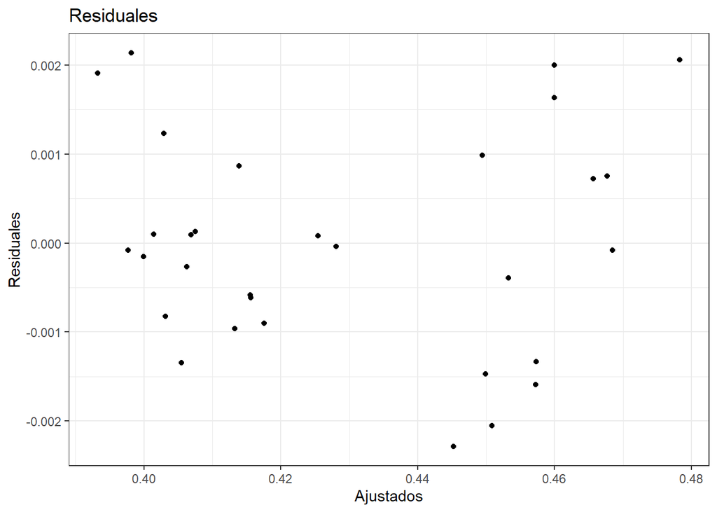

```r
# Análisis de residuales

train_res <- train_preds %>%
  mutate(res = share - media)

train_res %>%
  ggplot(aes(media, res)) +
  geom_point() +
  labs(title = 'Residuales', x = 'Ajustados', y = 'Residuales') +
  theme_bw()
```

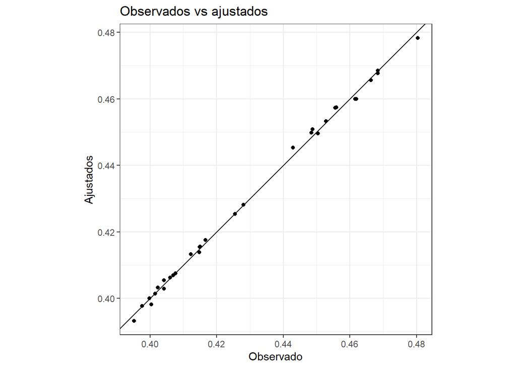

```r
# Gráfico de ajustados vs observados

train_preds %>%
  ggplot(aes(share, q_5)) +
  geom_point() +
  geom_abline(intercept = 0, slope = 1) +
  coord_equal() +
  labs(title = 'Observados vs ajustados', x = 'Observado', y = 'Ajustados') +
  theme(legend.position = 'bottom') +
  theme_bw()
```

```r
#Prediccióm

train_NIC2 <- train_NIC %>%
  rbind(test_NIC %>%
          mutate(share_A = NA))

jags_NIC2 <- list(
  share_A = train_NIC2$share_A,
  ventas_unidades_A = train_NIC2$ventas_unidades_A,
  ppu_A = train_NIC2$ppu_A,
  inventarios_A = train_NIC2$inventarios_A,
  ventas_unidades_B = train_NIC2$ventas_unidades_B,
  ppu_B = train_NIC2$ppu_B,
  inventarios_B = train_NIC2$inventarios_B,
  n = nrow(train_NIC),
  m = nrow(test_NIC)
)

#Parametros a guardar

jags_param_NIC2 <- c("be", "pred")

#JAGS
set.seed(1789152)
jags_model_NIC2 <- jags(jags_NIC2, jags.inits_NIC, jags_param_NIC2,
                   model.file = "libraries/modelo_fem_pronostico_NIC",
                   n.iter = 50000,
                   n.chains = 1,
                   n.thin = 1,
                   n.burnin = 5000)
jags_sims_NIC2 <- jags_model_NIC2$BUGSoutput$sims.matrix %>% as.data.frame()

train_preds_NIC <- jags_sims_NIC2 %>%
  dplyr::select(contains("pred")) %>%
  gather(parametro, sim) %>%
  mutate(mu_num = as.numeric(str_extract(parametro, '[0-9]+'))) %>%
  group_by(mu_num) %>%
  summarise(q_1 = quantile(sim, probs = 0.05),
            q_5 = median(sim),
            q_9 = quantile(sim, probs = 0.95),
            media = mean(sim)) %>%
  ungroup %>%
  cbind(share_A = train_NIC2$share_A) %>%
  dplyr::select(share_A, media, q_1:q_9)
```

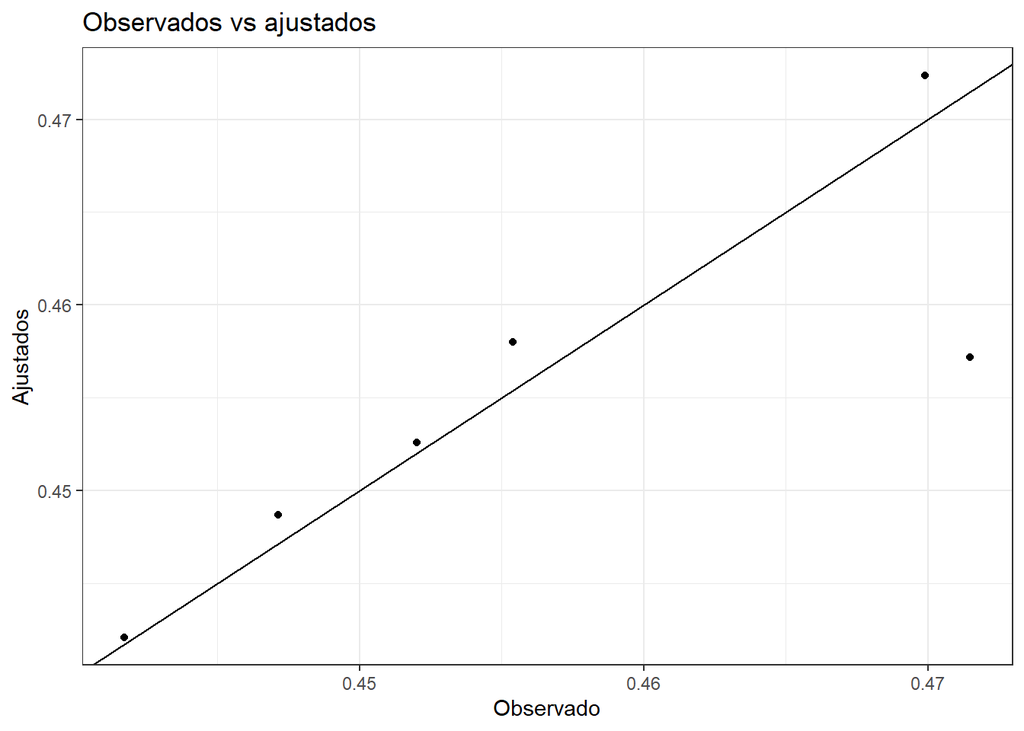

```r
ajuste_pronos_NIC <- train_preds_NIC %>%
  filter(is.na(share_A)) %>%
  dplyr::select(-share_A) %>%
  cbind(test_NIC %>% dplyr::select(share_A)) %>%
  dplyr::select(share_A, q_5)

cor_NIC <- cor(ajuste_pronos_NIC$share_A, ajuste_pronos_NIC$q_5)^2


ajuste_pronos_NIC %>%
  ggplot(aes(share_A, q_5)) +
  geom_point() +
  geom_abline(intercept = 0, slope = 1) +
  labs(title = 'Observados vs ajustados', x = 'Observado', y = 'Ajustados') +
  theme(legend.position = 'bottom') +
  theme_bw()
```